# Synchrony from multivariate models

Teresa Bohner

3/30/2020

## Overview

### Questions

1. How does synchrony of tree growth vary across regional/elevation gradients? Prediction: higher synchrony in lower latitude and lower elevation (drier) populations (SIASH, dendrochronological principles)
2. Within populations is intraspecific synchrony greater than interspecific synchrony? Between specific species pairs? With increasing distance? Prediction: higher synchrony among intraspecific pairs, potentially higher synchrony between pine pairs versus pine-fir pairs (successional stages), and lower synchrony with increasing distance
3. How has synchrony changed through time? Are changes more dramatic in certain populations? Is increased or decreased synchrony associated with certain environmental variables? Prediction: synchrony has increased with time, increased synchrony associated with drier, more variable time windows, changes are more pronounced in xeric populations.

Synchrony is explored here through residual correlations betweeen trees from multivariate models of tree growth.

We modeled the annual growth increment of all of the trees in a given neighborhood jointly to estimate their residual correlations (similar to calculating pearsons pairwise correlations).

*note difference in distribution with when keeping all of the draws versus summarizing median correlations.

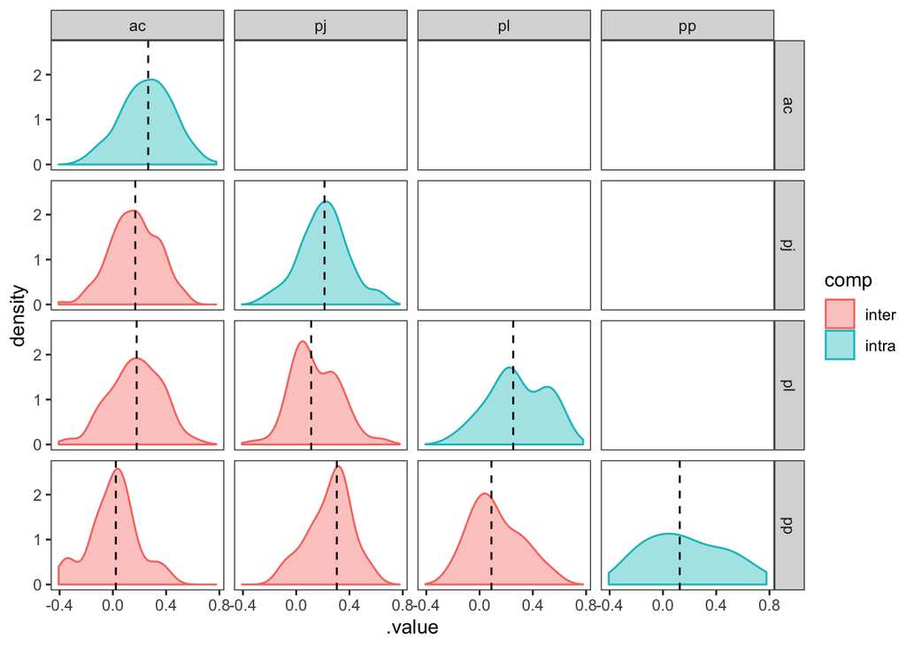

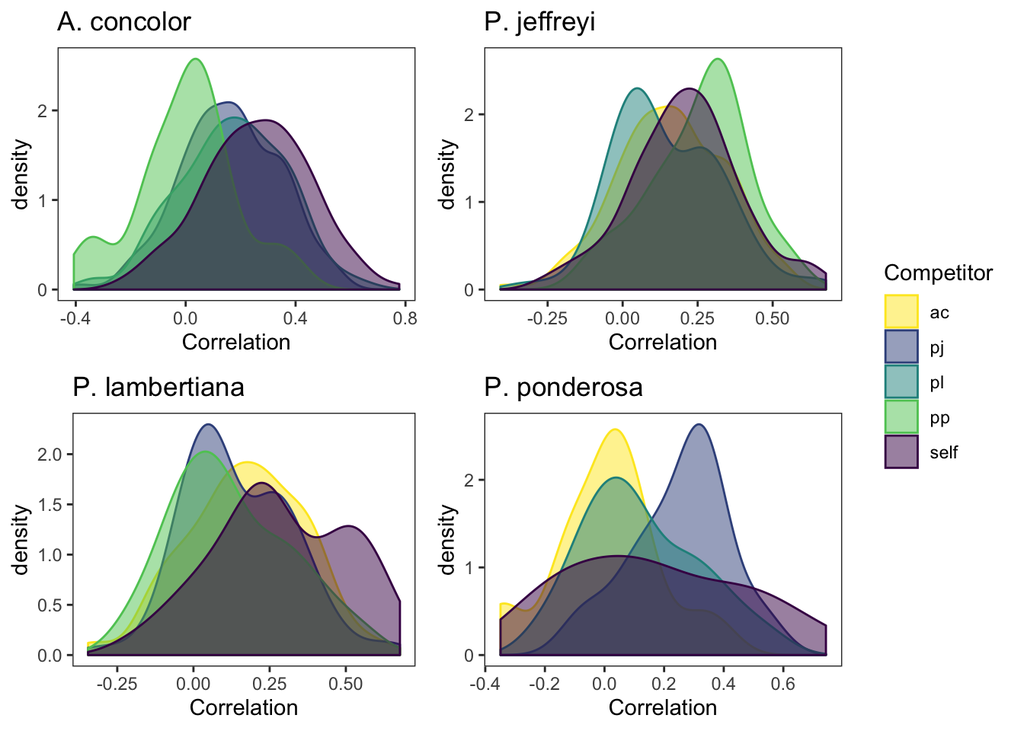

## Q3 Synchrony through time

Used 20 year time blocks overlapping 10 years

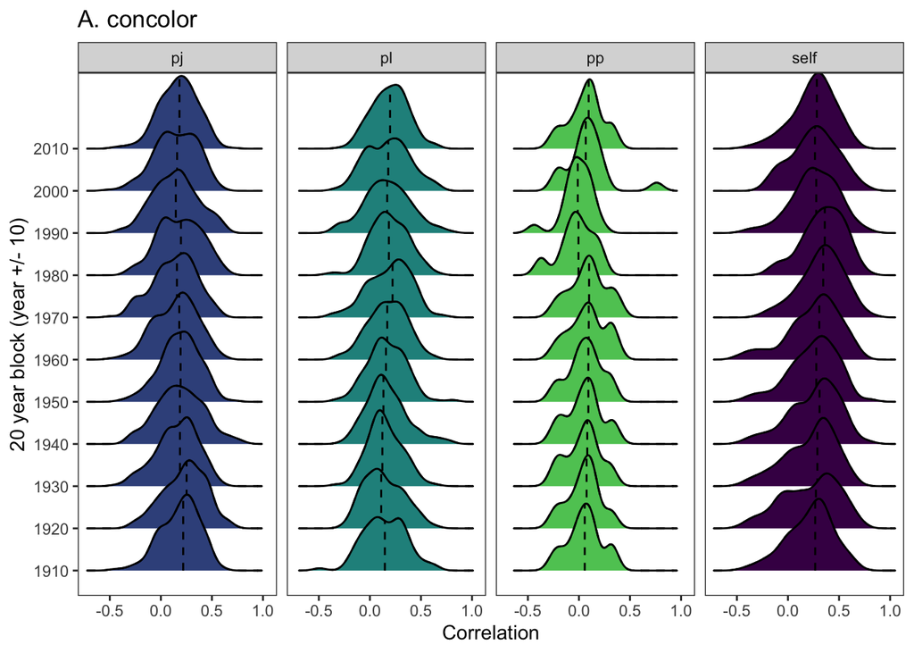

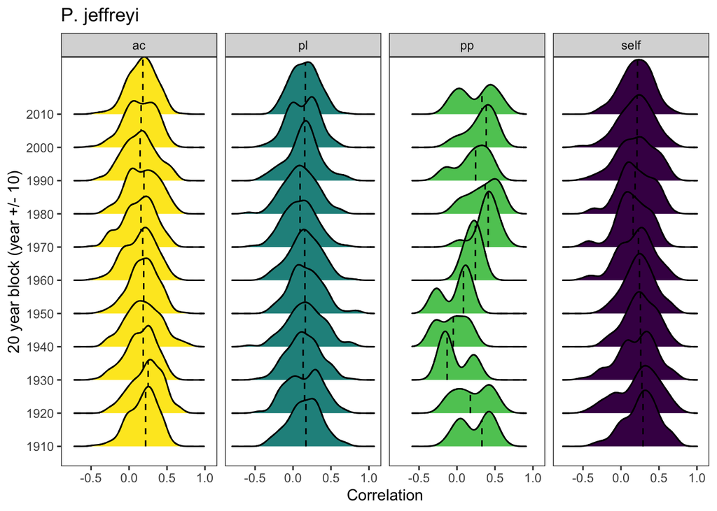

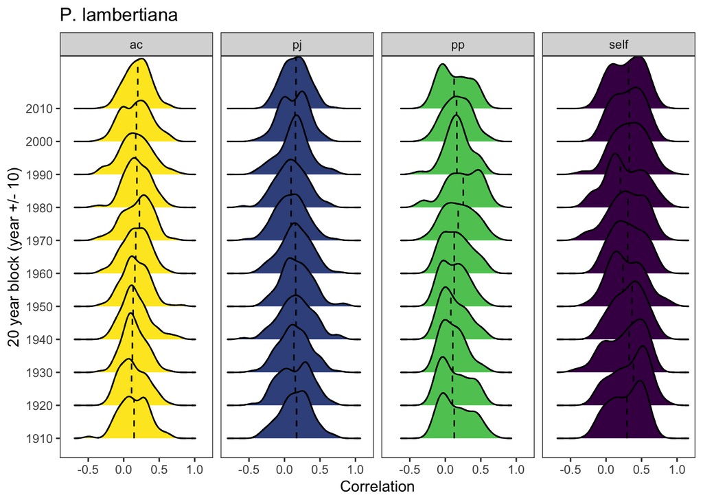

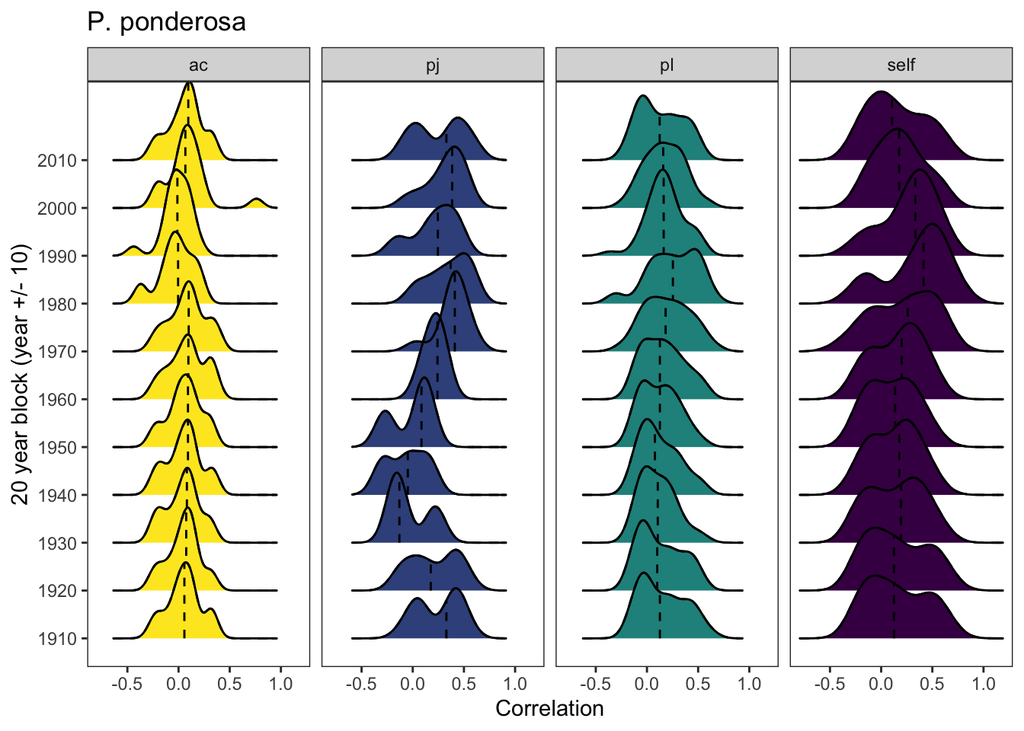

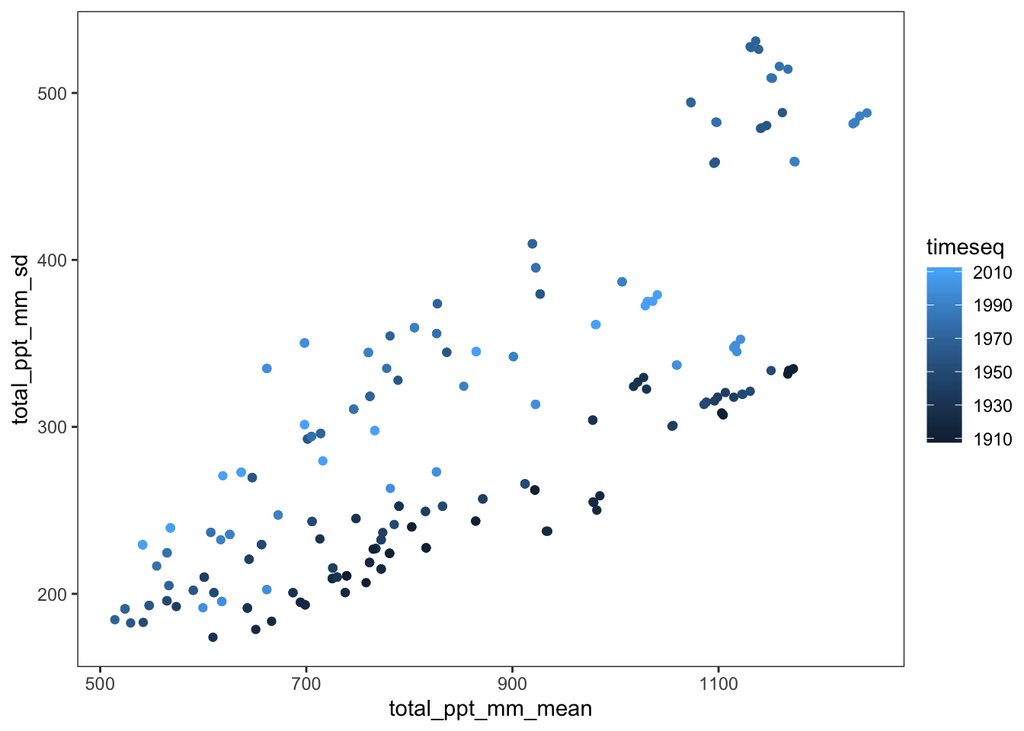

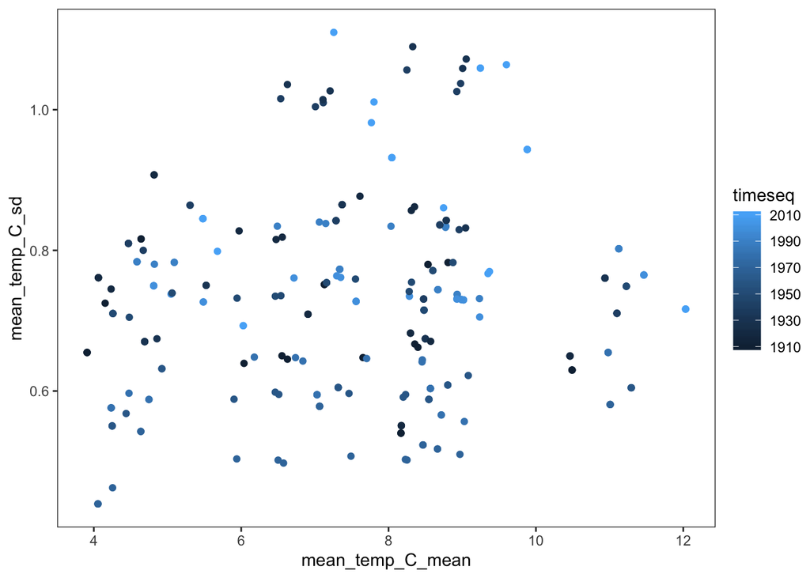

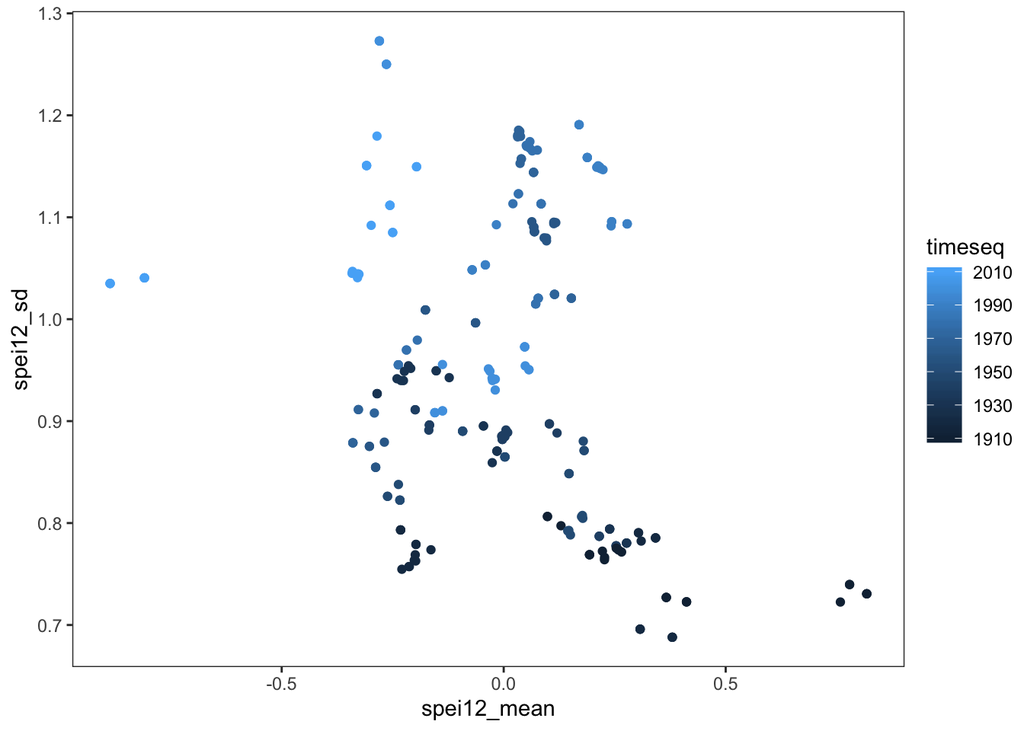